# 20-sfig5abcd-motif-validation: BPnet Cofactor Validation

Melanie (1028-02098-001-001)

August 19, 2019

# Introduction

BPnet returned motifs related to TFs and binding sites that it was not explicitly trained to understand. We want to validate that the TFs are binding to these sites of alternative motifs.

1. Validation of Zic3
2. Validation of Esrrb
3. Sox2, Pbx3, and Nanog ChIP-nexus across 5 motifs:
- 3 Nanog variants from BPNet (test)
- Sox2 motif from BPNet (positive control)
- Pbx motif from annotations (positive control)

# Computational Setup

```r
#Standard packages
source("https://bioconductor.org/biocLite.R")
library(rtracklayer) ; library(GenomicRanges); library(magrittr) ; library(Biostrings)
library(ggplot2) ; library(reshape2); library(plyranges); library(Rsamtools); library(data.table)
library(BSgenome.Mmusculus.UCSC.mm10); library(plyr); library(viridis); library(dplyr)

#KNITR Options
setwd("/n/projects/mw2098/publications/2019_bpnet/")
options(knitr.figure_dir="20-sfig5abcd-motif-validation", width=16, height=20)

#Lab sources
source("rscripts/granges_common.r")
source("rscripts/knitr_common.r")
source("rscripts/caching.r")
source("rscripts/multiplot.R")
source("rscripts/metapeak_functions.R")
source("rscripts/metapeak_common.r")

#Specific packages
library(stringr)
library(gridExtra)
library(motifStack)
```

# Define data paths

```r
#BED file with coordinates of each seqlet location returned by TF-MoDISco.
seqlet_coordinates_filepath <- "data/bed/seqlet_coordinates.bed"

#List of ChIP-nexus samples that were combined across replicates, blacklisted according to mm10, and normalized to reads per million (RPM).
bw.list<-list(oct4 = list(pos = "data/bw/nexus/mesc_oct4_nexus_combined_filtered_normalized_positive.bw",
                          neg = "data/bw/nexus/mesc_oct4_nexus_combined_filtered_normalized_negative.bw"),
              sox2 = list(pos = "data/bw/nexus/mesc_sox2_nexus_combined_filtered_normalized_positive.bw",
                          neg = "data/bw/nexus/mesc_sox2_nexus_combined_filtered_normalized_negative.bw"),
              nanog = list(pos="data/bw/nexus/mesc_nanog_nexus_combined_filtered_normalized_positive.bw",
                           neg="data/bw/nexus/mesc_nanog_nexus_combined_filtered_normalized_negative.bw"),
              klf4 = list(pos="data/bw/nexus/mesc_klf4_nexus_combined_filtered_normalized_positive.bw",
                          neg="data/bw/nexus/mesc_klf4_nexus_combined_filtered_normalized_negative.bw"),
              zic3 = list(pos="data/bw/nexus/mesc_zic3_nexus_combined_filtered_normalized_positive.bw",
                           neg="data/bw/nexus/mesc_zic3_nexus_combined_filtered_normalized_negative.bw"),
              esrrb = list(pos="data/bw/nexus/mesc_esrrb_nexus_combined_filtered_normalized_positive.bw",
                           neg="data/bw/nexus/mesc_esrrb_nexus_combined_filtered_normalized_negative.bw"),
              pbx = list(pos="data/bw/nexus/mesc_pbx_nexus_combined_filtered_normalized_positive.bw",
                           neg="data/bw/nexus/mesc_pbx_nexus_combined_filtered_normalized_negative.bw"))
```

# Function to plot motifs

```r
plot_chipnexus_across_motifs<-function(motif, sample, title, ylim=NA, upstream=100, downstream=100, plot=T){
  metapeak<-exo_metapeak(gr = resize(motif, 1), sample_name = title, sample=sample, upstream=upstream, downstream=downstream)
  colnames(metapeak)<-c("position", "norm_reads", "strand", "name", "sample")
  if(plot){
  g<-ggplot(metapeak, aes(position, norm_reads, color=strand, group=strand))+
    geom_rect(aes(ymin=-Inf, ymax=Inf, xmin=0, xmax = width(motif)[1]), alpha=.1, fill="gray90", color="transparent")+
    geom_line(size=1)+
    scale_color_manual(values = c("indianred3", "navy"), name="Strand")+
    scale_y_continuous(name="Normalized reads")+
    scale_x_continuous(name="Position w.r.t. motif start")+
    ggtitle(title)+
    theme_classic()+
    theme(text=element_text(size=20))
  if(!is.na(ylim[1])){g<-g+scale_y_continuous(limits=ylim, name="Normalized reads")}
  return(g)
  }
  else{return(metapeak)}
}
```

# Validate Zic3 motif returned by TF-MoDISco

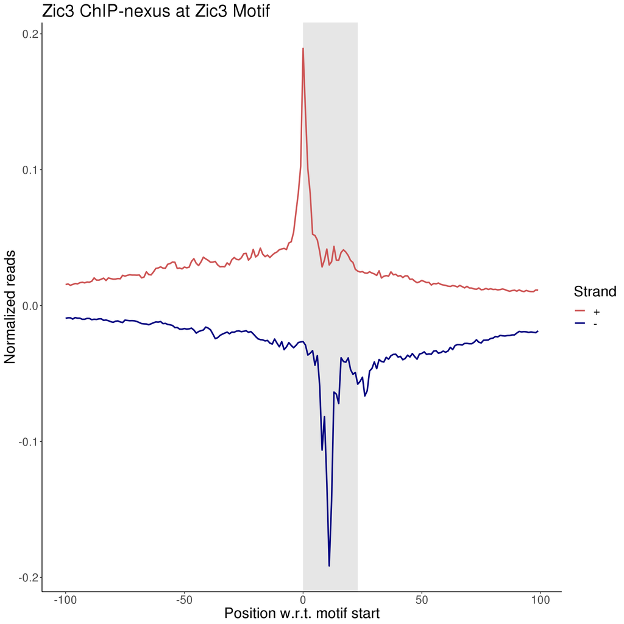

```r
zic3_specific_motif<-import(seqlet_coordinates_filepath) %>% subset(., name=="Klf4_2")
zic3_chip_across_zic_motif<-plot_chipnexus_across_motifs(motif=zic3_specific_motif, title = "Zic3 ChIP-nexus at Zic3 Motif", #ylim=c(-.015, .015),
                                                         sample = bw.list$zic3)
print(zic3_chip_across_zic_motif)
```

# Validate Esrrb motif returned by TF-MoDISco

## Esrrb ChIP at Esrrb motif (BPNet)

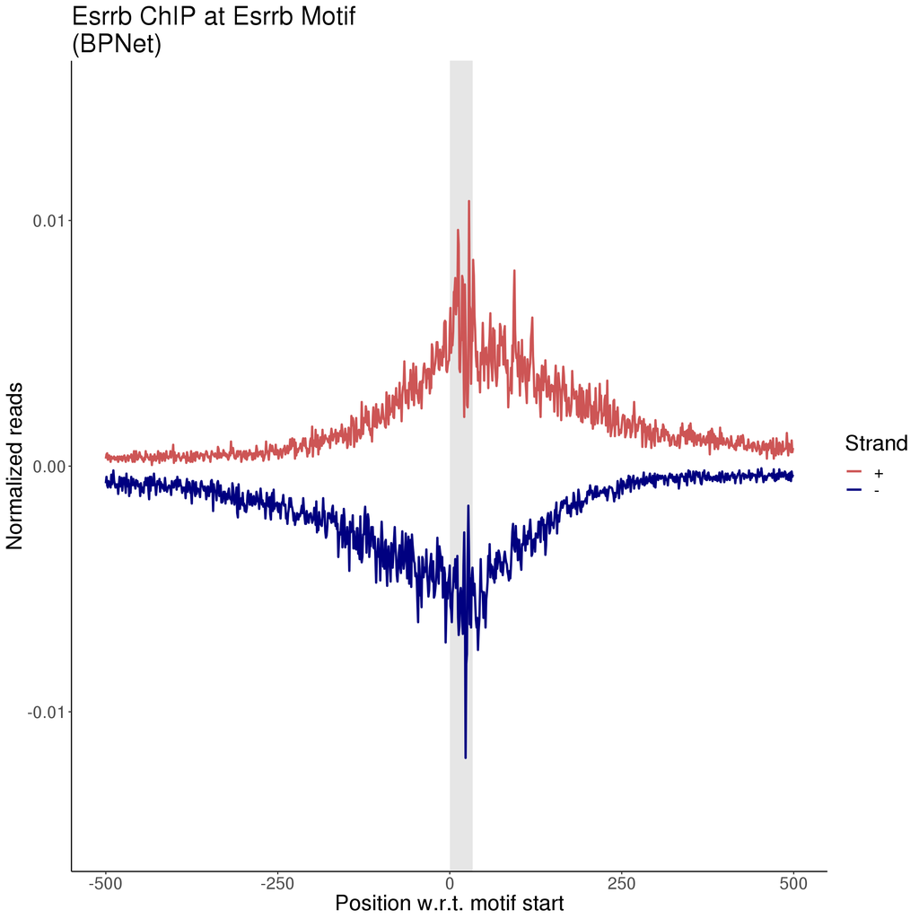

```r
#Esrrb ChIP at Esrrb-specific motif
esrrb_specific_motif<-import(seqlet_coordinates_filepath) %>% subset(., name=="Oct4_16")
esrrb_chip_across_esrrb_motif<-plot_chipnexus_across_motifs(motif=esrrb_specific_motif, title = "Esrrb ChIP at Esrrb Motif\n(BPNet)",
                                                            upstream = 500, downstream = 500, ylim=c(-.015, .015),
                                                            sample = bw.list$esrrb)
print(esrrb_chip_across_esrrb_motif)
```

## Esrrb ChIP at Esrrb motif (Non-BPnet)

### Find Esrrb motif locations across genome through sequence match

```r
esrrb_motif_across_genome <- DNAString("TCAAGGTCA") %>%
  vmatchPattern(., BSgenome.Mmusculus.UCSC.mm10, max.mismatch =0, fixed = "subject")
saveRDS("data/rdata/motif_locations/esrrb_TCAAGGTCA_motif_instances_0_mm.rds")
```

### Plot matches

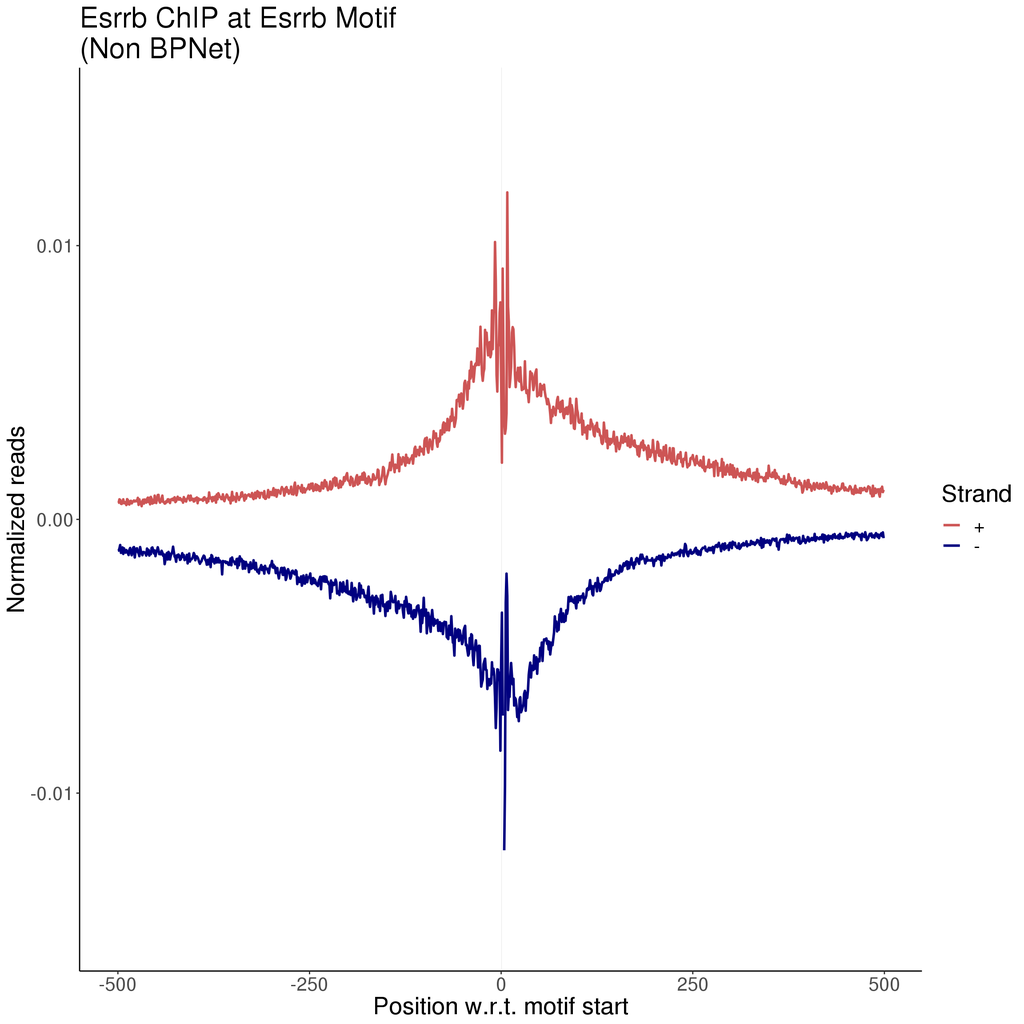

```r
#Esrrb ChIP at Esrrb-specific motif
esrrb_motif_instances<-readRDS("data/rdata/motif_locations/esrrb_TCAAGGTCA_motif_instances_0_mm.rds")

#Switch strand to match BPnet orientation
neg_idx<-which(strand(esrrb_motif_instances)=="-")
pos_idx<-which(strand(esrrb_motif_instances)=="+")
strand(esrrb_motif_instances[neg_idx])<-"+"
strand(esrrb_motif_instances[pos_idx])<-"-"

#Select top 1K instances that score for Esrrb
esrrb_motif_instances$esrrb_score<-regionMeans(esrrb_motif_instances, bw.list$esrrb$pos) +
  abs(regionMeans(resize(esrrb_motif_instances, 100, "center"), bw.list$esrrb$neg))
esrrb_motif_instances<-esrrb_motif_instances[order(esrrb_motif_instances$esrrb_score, decreasing=T)][1:1000]

esrrb_chip_across_esrrb_motif<-plot_chipnexus_across_motifs(motif=resize(esrrb_motif_instances, 1),
                                                            title = "Esrrb ChIP at Esrrb Motif \n(Non BPNet)", upstream = 500, downstream = 500, ylim=c(-.015, .015),
                                                            sample = bw.list$esrrb)
print(esrrb_chip_across_esrrb_motif)
```

### Get PWM motif

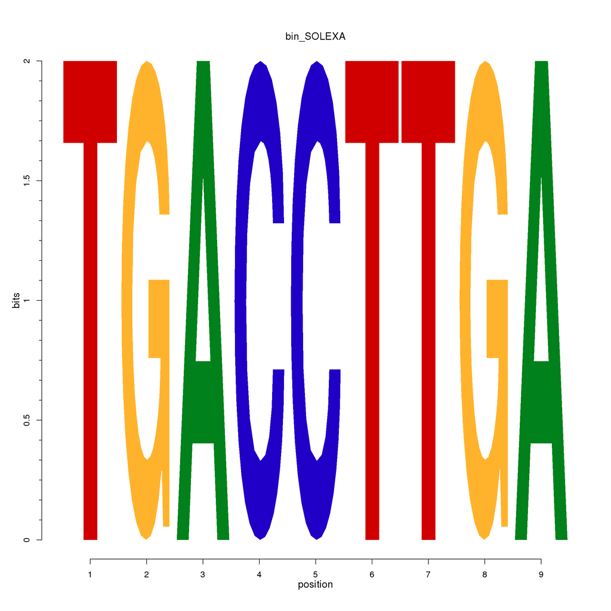

```r
esrrb_motif_instances_subset<-esrrb_motif_instances
esrrb_motif_instances_subset$seq<-getSeq(BSgenome.Mmusculus.UCSC.mm10, esrrb_motif_instances_subset)
esrrb_motif_instances_pwm<-PWM(esrrb_motif_instances_subset$seq, type="prob")
motif <- new("pcm", mat=as.matrix(esrrb_motif_instances_pwm), name="bin_SOLEXA")
plot(motif)
```

# Validate 3 Nanog motifs, Sox2 and Pbx returned by TF-MoDISco

We want to validate the 3 Nanog motifs are Nanog-specific, showing also that Sox2 and Pbx serve as a positive control where Nanog is not specifically bound.

## Import Nanog variants

The three Nanog variant motifs should be imported and aligned to their TCA components.

```r
reshape_motifs<-function(gr, reposition_by){
  is_pos<-strand(gr)=="+"
  gr[is_pos]<-IRanges::shift(gr[is_pos], shift=reposition_by)
  gr[!is_pos]<-IRanges::shift(gr[!is_pos], shift=-reposition_by)
  gr
}

#import and trim motifs
nanog_1<-import(seqlet_coordinates_filepath) %>% subset(., name=="Nanog_1")
nanog_1$seq<-getSeq(BSgenome.Mmusculus.UCSC.mm10, nanog_1)
nanog_1_trimmed<-reshape_motifs(nanog_1 %>% resize(width=1, fix="start"), reposition_by = 5)

nanog_4<-import(seqlet_coordinates_filepath) %>% subset(., name=="Nanog_4")
nanog_4$seq<-getSeq(BSgenome.Mmusculus.UCSC.mm10, nanog_4)
nanog_4_trimmed<-reshape_motifs(nanog_4 %>% resize(width=1, fix="start"), reposition_by = 10)

#Switch strand for nanog_4, it is reverse complemented
nanog_4_rev<-nanog_4
strand(nanog_4_rev[strand(nanog_4)=="+"])<-"-"
strand(nanog_4_rev[strand(nanog_4)=="-"])<-"+"
nanog_4_trim_rev<-reshape_motifs(nanog_4_rev %>% resize(width=1, fix="start"), reposition_by = 13)

nanog_5<-import(seqlet_coordinates_filepath) %>% subset(., name=="Nanog_5")
nanog_5$seq<-getSeq(BSgenome.Mmusculus.UCSC.mm10, nanog_5)
nanog_5_trimmed<-reshape_motifs(nanog_5 %>% resize(width=1, fix="start"), reposition_by = 11)

#Combine
nanog_trimmed_motifs_aligned_to_TCA<-c(nanog_1_trimmed, nanog_4_trim_rev, nanog_5_trimmed)
```

`nanog_trimmed_motifs_aligned_to_TCA` are a single nucleotide wide occupying the T in TCA.

The sequence is (relative to Nanog_4): GGAAATGGGC?A*T*CAA

### Resize to motif distance

Once aligned, resize to the correct motif distance

```r
nanog_1_motifs<-resize(resize(nanog_1_trimmed, 13, "end"), 16, "start")
nanog_4_motifs<-resize(resize(nanog_4_trim_rev, 13, "end"), 16, "start")
nanog_5_motifs<-resize(resize(nanog_5_trimmed, 13, "end"), 16, "start")
```

## Import Sox2 motif

```r
sox2_1_motifs<-import(seqlet_coordinates_filepath) %>% subset(., name=="Nanog_3")
sox2_1_motifs$seq<-getSeq(BSgenome.Mmusculus.UCSC.mm10, sox2_1_motifs)
```

## Import Pbx motif

### Find Pbx motif locations across genome through sequence match

```r
pbx_motif_across_genome <- DNAString("TGAKTGACAGG") %>%
  vmatchPattern(., BSgenome.Mmusculus.UCSC.mm10, max.mismatch =0, fixed = "subject")
saveRDS("data/rdata/motif_locations/pbx_TGAKTGACAGG_motif_instances_0_mm.rds")
```

## Compute top scoring Pbx motif locations

```r
pbx_motif_instances<-readRDS("data/rdata/motif_locations/pbx_TGAKTGACAGG_motif_instances_0_mm.rds") %>%
  keepStandardChromosomes(species="Mus_musculus", pruning.mode = "coarse")
pbx_motif_instances$pbx_score<-regionMeans(resize(pbx_motif_instances, 100, "center"), bw.list$pbx$pos) +
  abs(regionMeans(resize(pbx_motif_instances, 100, "center"), bw.list$pbx$neg))
pbx_motif_instances<-pbx_motif_instances[order(pbx_motif_instances$pbx_score, decreasing=T)][1:5000]
```

## Collect motifs

```r
motifs.list<-list(Nanog = (nanog_1_motifs %>% granges),
                  Nanog_mix = (nanog_5_motifs %>% granges),
                  Nanog_alt = (nanog_4_motifs %>% granges),
                  Sox2 = (sox2_1_motifs %>% granges),
                  Pbx = (pbx_motif_instances %>% granges))
lapply(motifs.list, length)
```

```
## $Nanog
## [1] 2981
##
## $Nanog_mix
## [1] 602
##
## $Nanog_alt
## [1] 753
##
## $Sox2
## [1] 788
##
## $Pbx
## [1] 5000
```

## Generate metapeaks

Across 5 motifs and 3 factors, generate 15 metapeaks.

```r
metapeaks<-lapply(names(motifs.list), function(x){
  mclapply(c("pbx", "sox2", "nanog"), function(y){
    message(x, "_", y)
    metapeak<-exo_metapeak(gr = resize(motifs.list[[x]], 1),
                 sample = bw.list[[y]],
                 upstream = 50, downstream = 50)
    metapeak$fac<-y
    metapeak$motif<-x
    metapeak
  }, mc.cores=3) %>% rbindlist
}) %>% rbindlist
```

## Plot metapeaks

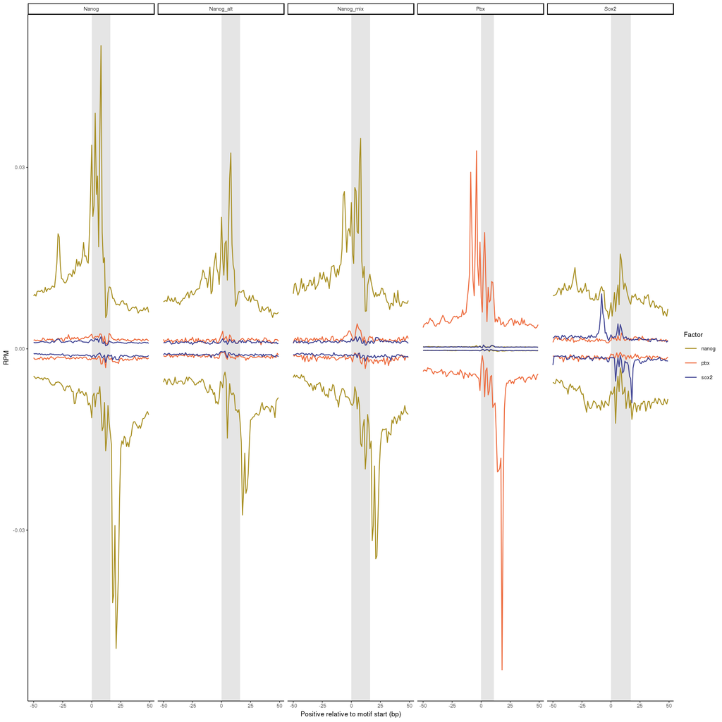

```r
metapeaks$fac<-factor(metapeaks$fac, levels=c("nanog", "pbx", "sox2"))
metapeaks$motif<-factor(metapeaks$motif)
metapeaks$strand<-factor(metapeaks$strand)

motif_widths<-lapply(names(motifs.list), function(x) data.frame(motif=x, width=width(motifs.list[[x]])[1])) %>% rbindlist()

g_with_subheaders<-ggplot(metapeaks)+
  geom_rect(data=motif_widths, aes(xmin=0, xmax=width, ymin=-Inf, ymax=Inf), alpha=.2, fill="gray50")+
  geom_line(aes(x=tss_distance, y=reads, color=fac, group=interaction(fac, strand)))+
  scale_color_manual(name="Factor", values=c("#A68D1E", "#ED693B", "#3B3F91"))+
  scale_x_continuous(name="Positive relative to motif start (bp)")+
  scale_y_continuous(name="RPM")+
  facet_grid(. ~ motif)+
  theme_classic(base_size = 8)
print(g_with_subheaders)
```